# Instructions

Leandro

2023-05-16

1 - Click in “Browse”

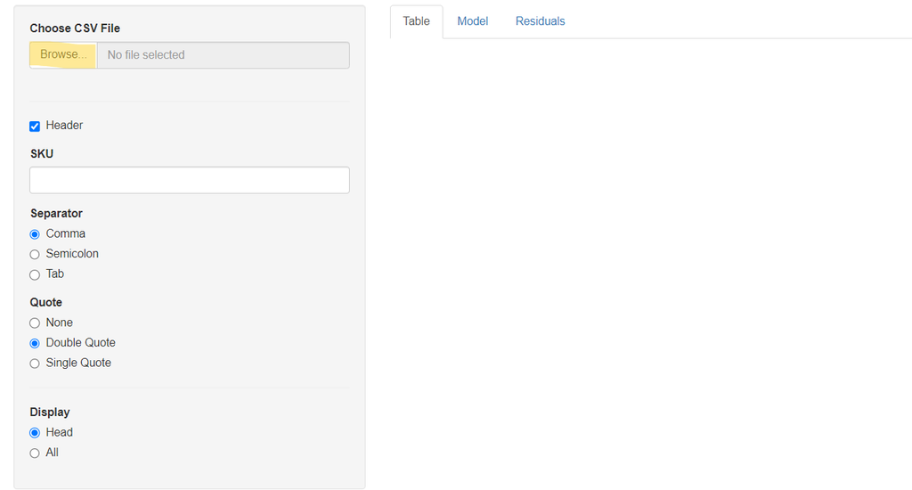

2 - Load the csv file containing the Historical data.

**Important**

The layout of this document must be:

1st column - SKU code

2nd column - Demand

3rd column - Period in a text format “YYYY-MM”.

[figure not shown]

3 - After loaded, you may see a table with the loaded data

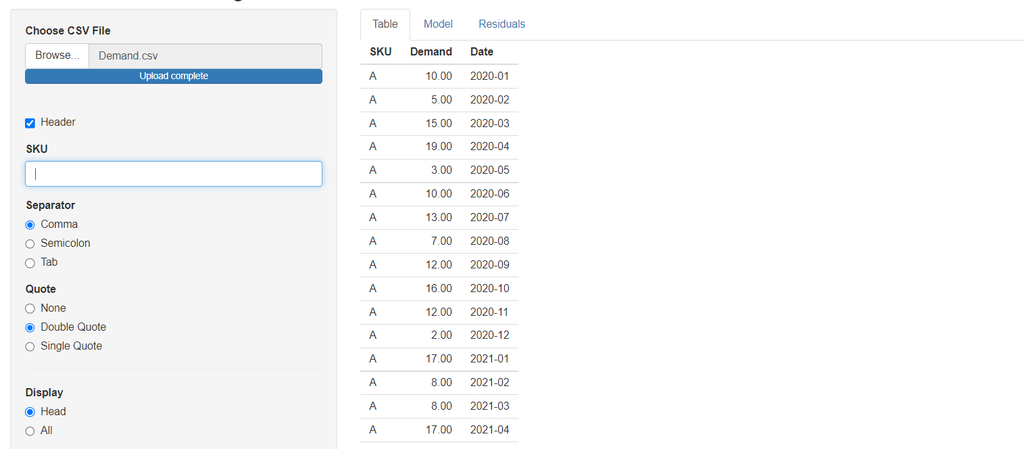

4 - In the field “SKU” inform the desired sku.

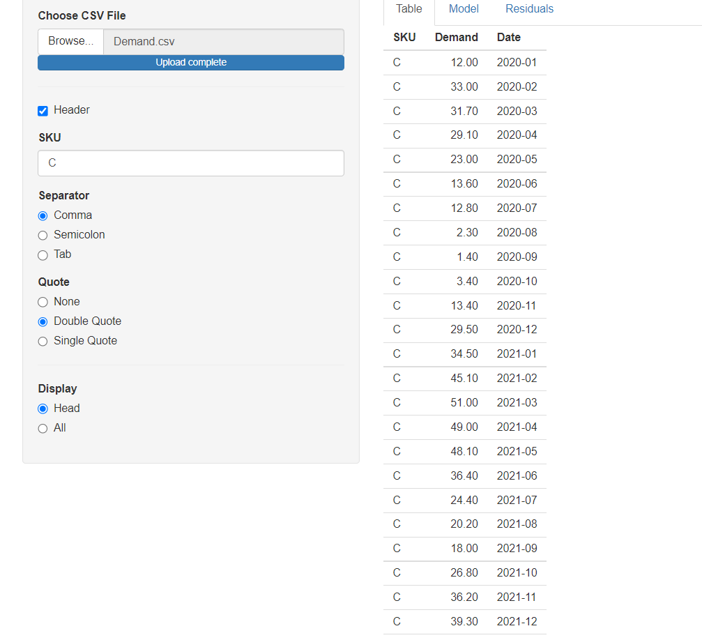

5 - In the tab “Model” you will see the chosen model, the estimation including the range representing 95% of confidence interval and a plot with historical and estimated data

5.1 - In this first example (an item with seasonal and trend pattern) the model chosen was an seasonal pattern with lag 12 [12] seasonal autoregressive order (1) and seasonal difference order I(1). In essence, the model SARIMA (0,0,0)(1,1,0)[12]

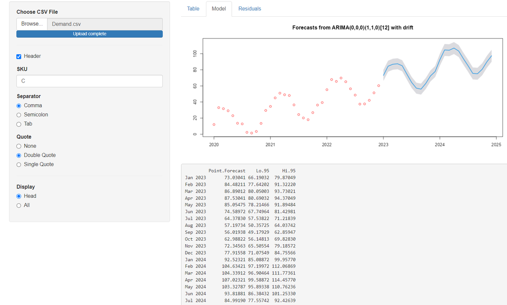

5.2 - In this second example, a simulated demand of an item with only a positive trend pattern. The chosen model was a single AR(2) with 1 differentiation I(1)

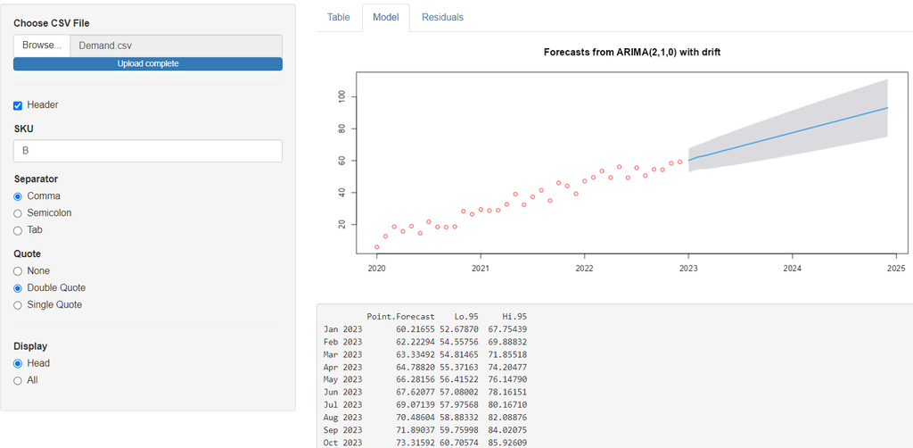

5.3 - For items without any pattern, only a moving average was enough. In this example the model chosen was an ARIMA(0,0,2).

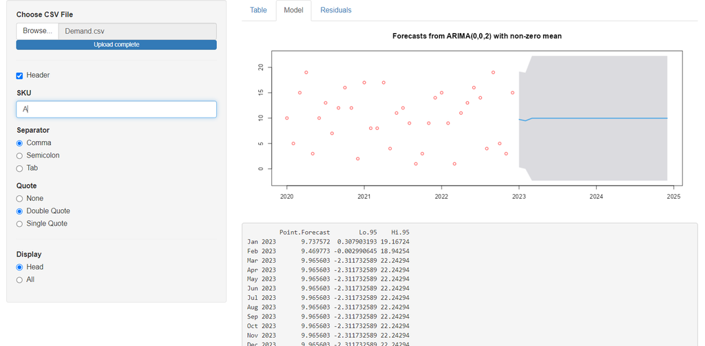

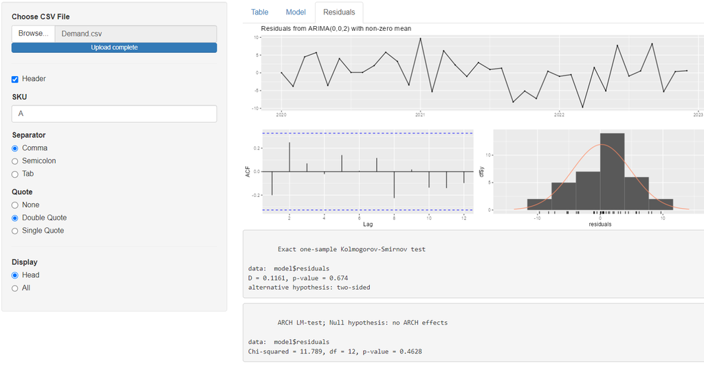

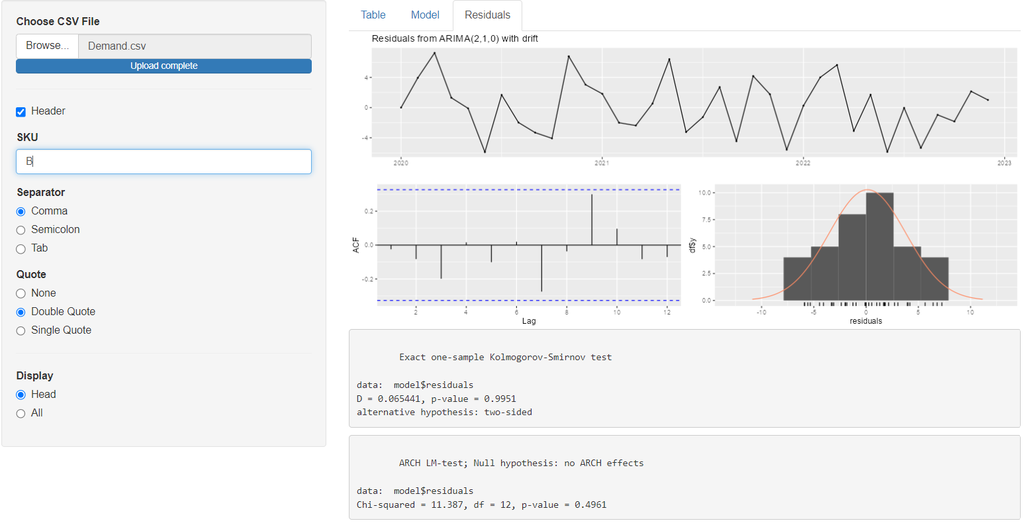

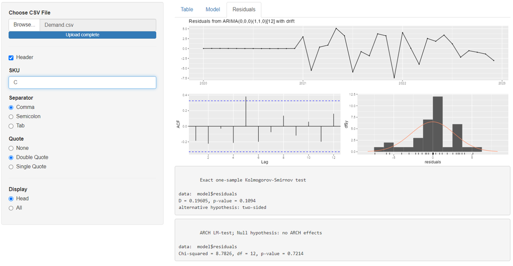